# Risk Factor Analysis

## Outcome Variable

**Outcome Variable:** haz

## Predictor Variables

**Intervention Variable:** feducyrs

**Adjustment Set:**

- arm
- W_mage
- meducyrs
- hhwealth_quart
- W_mhtcm
- W_gagebrth
- W_birthwt
- W_birthlen
- single
- delta_W_mage
- delta_meducyrs
- delta_hhwealth_quart
- delta_W_mhtcm
- delta_W_gagebrth
- delta_W_birthwt
- delta_W_birthlen
- delta_single

## Stratifying Variables

The analysis was stratified on these variable(s):

- agecat
- studyid
- country

## Data Summary

| agecat | studyid | country | feducyrs | n_cell | n |
| --- | --- | --- | --- | --- | --- |
| Birth | ki0047075b-MAL-ED | BANGLADESH | High | 52 | 144 |
| Birth | ki0047075b-MAL-ED | BANGLADESH | Low | 38 | 144 |
| Birth | ki0047075b-MAL-ED | BANGLADESH | Medium | 54 | 144 |
| Birth | ki0047075b-MAL-ED | INDIA | High | 38 | 123 |
| Birth | ki0047075b-MAL-ED | INDIA | Low | 50 | 123 |
| Birth | ki0047075b-MAL-ED | INDIA | Medium | 35 | 123 |
| Birth | ki0047075b-MAL-ED | NEPAL | High | 27 | 67 |
| Birth | ki0047075b-MAL-ED | NEPAL | Low | 19 | 67 |
| Birth | ki0047075b-MAL-ED | NEPAL | Medium | 21 | 67 |
| Birth | ki0047075b-MAL-ED | PERU | High | 116 | 236 |
| Birth | ki0047075b-MAL-ED | PERU | Low | 65 | 236 |
| Birth | ki0047075b-MAL-ED | PERU | Medium | 55 | 236 |
| Birth | ki0047075b-MAL-ED | SOUTH AFRICA | High | 35 | 91 |
| Birth | ki0047075b-MAL-ED | SOUTH AFRICA | Low | 30 | 91 |
| Birth | ki0047075b-MAL-ED | SOUTH AFRICA | Medium | 26 | 91 |
| Birth | ki0047075b-MAL-ED | TANZANIA, UNITED REPUBLIC OF | High | 65 | 101 |
| Birth | ki0047075b-MAL-ED | TANZANIA, UNITED REPUBLIC OF | Low | 29 | 101 |
| Birth | ki0047075b-MAL-ED | TANZANIA, UNITED REPUBLIC OF | Medium | 7 | 101 |
| Birth | ki1000304b-SAS-CompFeed | INDIA | High | 34 | 187 |
| Birth | ki1000304b-SAS-CompFeed | INDIA | Low | 79 | 187 |
| Birth | ki1000304b-SAS-CompFeed | INDIA | Medium | 74 | 187 |
| Birth | ki1017093c-NIH-Crypto | BANGLADESH | High | 8 | 27 |
| Birth | ki1017093c-NIH-Crypto | BANGLADESH | Low | 12 | 27 |
| Birth | ki1017093c-NIH-Crypto | BANGLADESH | Medium | 7 | 27 |
| Birth | ki1119695-PROBIT | BELARUS | High | 2058 | 13416 |
| Birth | ki1119695-PROBIT | BELARUS | Low | 5316 | 13416 |
| Birth | ki1119695-PROBIT | BELARUS | Medium | 6042 | 13416 |
| Birth | ki1126311-ZVITAMBO | ZIMBABWE | High | 976 | 13460 |
| Birth | ki1126311-ZVITAMBO | ZIMBABWE | Low | 2276 | 13460 |
| Birth | ki1126311-ZVITAMBO | ZIMBABWE | Medium | 10208 | 13460 |

[output cut: 129 more lines]

The following strata were considered:

- agecat: 24 months, studyid: ki0047075b-MAL-ED, country: BANGLADESH
- agecat: 24 months, studyid: ki0047075b-MAL-ED, country: INDIA
- agecat: 24 months, studyid: ki0047075b-MAL-ED, country: NEPAL
- agecat: 24 months, studyid: ki0047075b-MAL-ED, country: PERU
- agecat: 24 months, studyid: ki0047075b-MAL-ED, country: SOUTH AFRICA
- agecat: 24 months, studyid: ki0047075b-MAL-ED, country: TANZANIA, UNITED REPUBLIC OF
- agecat: 24 months, studyid: ki1017093b-PROVIDE, country: BANGLADESH
- agecat: 24 months, studyid: ki1017093c-NIH-Crypto, country: BANGLADESH
- agecat: 24 months, studyid: ki1066203-TanzaniaChild2, country: TANZANIA, UNITED REPUBLIC OF
- agecat: 24 months, studyid: ki1113344-GMS-Nepal, country: NEPAL
- agecat: 24 months, studyid: ki1119695-PROBIT, country: BELARUS
- agecat: 24 months, studyid: ki1126311-ZVITAMBO, country: ZIMBABWE
- agecat: 24 months, studyid: ki1135781-COHORTS, country: GUATEMALA
- agecat: 24 months, studyid: ki1135781-COHORTS, country: INDIA
- agecat: 24 months, studyid: ki1135781-COHORTS, country: PHILIPPINES
- agecat: 24 months, studyid: ki1148112-LCNI-5, country: MALAWI
- agecat: 24 months, studyid: kiGH5241-JiVitA-3, country: BANGLADESH
- agecat: 24 months, studyid: kiGH5241-JiVitA-4, country: BANGLADESH
- agecat: 6 months, studyid: ki0047075b-MAL-ED, country: BANGLADESH
- agecat: 6 months, studyid: ki0047075b-MAL-ED, country: INDIA
- agecat: 6 months, studyid: ki0047075b-MAL-ED, country: NEPAL
- agecat: 6 months, studyid: ki0047075b-MAL-ED, country: PERU
- agecat: 6 months, studyid: ki0047075b-MAL-ED, country: SOUTH AFRICA
- agecat: 6 months, studyid: ki0047075b-MAL-ED, country: TANZANIA, UNITED REPUBLIC OF
- agecat: 6 months, studyid: ki1000304b-SAS-CompFeed, country: INDIA
- agecat: 6 months, studyid: ki1000304b-SAS-FoodSuppl, country: INDIA
- agecat: 6 months, studyid: ki1017093b-PROVIDE, country: BANGLADESH
- agecat: 6 months, studyid: ki1017093c-NIH-Crypto, country: BANGLADESH
- agecat: 6 months, studyid: ki1066203-TanzaniaChild2, country: TANZANIA, UNITED REPUBLIC OF
- agecat: 6 months, studyid: ki1113344-GMS-Nepal, country: NEPAL
- agecat: 6 months, studyid: ki1119695-PROBIT, country: BELARUS
- agecat: 6 months, studyid: ki1126311-ZVITAMBO, country: ZIMBABWE
- agecat: 6 months, studyid: ki1135781-COHORTS, country: GUATEMALA
- agecat: 6 months, studyid: ki1135781-COHORTS, country: INDIA
- agecat: 6 months, studyid: ki1135781-COHORTS, country: PHILIPPINES
- agecat: 6 months, studyid: ki1148112-LCNI-5, country: MALAWI
- agecat: 6 months, studyid: kiGH5241-JiVitA-3, country: BANGLADESH
- agecat: 6 months, studyid: kiGH5241-JiVitA-4, country: BANGLADESH
- agecat: Birth, studyid: ki0047075b-MAL-ED, country: BANGLADESH
- agecat: Birth, studyid: ki0047075b-MAL-ED, country: INDIA
- agecat: Birth, studyid: ki0047075b-MAL-ED, country: NEPAL
- agecat: Birth, studyid: ki0047075b-MAL-ED, country: PERU
- agecat: Birth, studyid: ki0047075b-MAL-ED, country: SOUTH AFRICA
- agecat: Birth, studyid: ki0047075b-MAL-ED, country: TANZANIA, UNITED REPUBLIC OF
- agecat: Birth, studyid: ki1000304b-SAS-CompFeed, country: INDIA
- agecat: Birth, studyid: ki1017093c-NIH-Crypto, country: BANGLADESH
- agecat: Birth, studyid: ki1119695-PROBIT, country: BELARUS
- agecat: Birth, studyid: ki1126311-ZVITAMBO, country: ZIMBABWE
- agecat: Birth, studyid: ki1135781-COHORTS, country: GUATEMALA
- agecat: Birth, studyid: ki1135781-COHORTS, country: INDIA
- agecat: Birth, studyid: ki1135781-COHORTS, country: PHILIPPINES
- agecat: Birth, studyid: kiGH5241-JiVitA-3, country: BANGLADESH
- agecat: Birth, studyid: kiGH5241-JiVitA-4, country: BANGLADESH

### Dropped Strata

Some strata were dropped due to rare outcomes:

- agecat: 24 months, studyid: ki1066203-TanzaniaChild2, country: TANZANIA, UNITED REPUBLIC OF

## Methods Detail

We’re interested in the causal parameters $E[Y_a]$ for all values of $a \in \mathcal{A}$. These parameters represent the mean outcome if, possibly contrary to fact, we intervened to set all units to have $A=a$. Under the randomization and positivity assumptions, these are identified by the statistical parameters $\psi_a=E_W[E_{Y|A,W}(Y|A=a,W)]$. In addition, we’re interested in the mean of $Y$, $E[Y]$ under no intervention (the observed mean). We will estimate these parameters by using SuperLearner to fit the relevant likelihood factors – $E_{Y|A,W}(Y|A=a,W)$ and $p(A=a|W)$, and then updating our likelihood fit using a joint TMLE.

For unadjusted analyses ($W=\{\}$), initial likelihoods were estimated using Lrnr_glm to estimate the simple $E(Y|A)$ and Lrnr_mean to estimate $p(A)$. For adjusted analyses, a small library containing Lrnr_glmnet, Lrnr_xgboost, and Lrnr_mean was used.

Having estimated these parameters, we will then use the delta method to estimate relative risks and attributable risks relative to a prespecified baseline level of $A$.

# Results Detail

## Results Plots

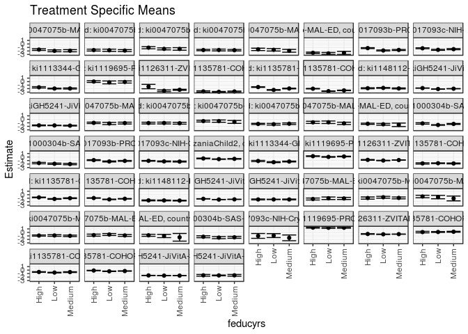

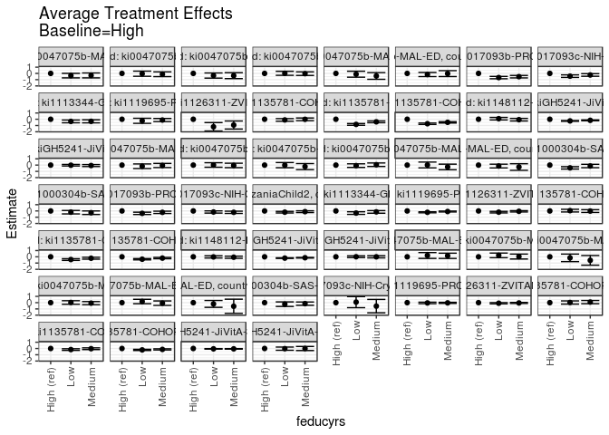

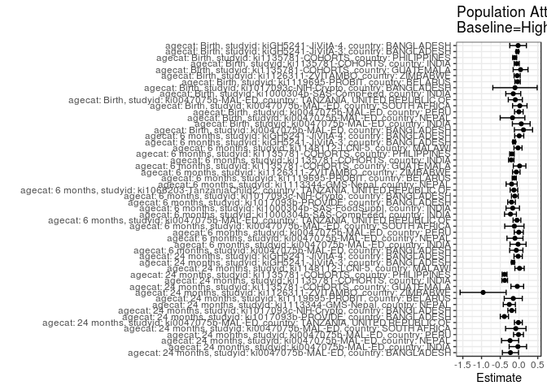

## Results Table

### Parameter: TSM

| agecat | studyid | country | intervention_level | baseline_level | estimate | ci_lower | ci_upper |
| --- | --- | --- | --- | --- | --- | --- | --- |
| Birth | ki0047075b-MAL-ED | BANGLADESH | High | NA | -1.2292632 | -1.5102947 | -0.9482316 |
| Birth | ki0047075b-MAL-ED | BANGLADESH | Low | NA | -1.0198062 | -1.3879454 | -0.6516671 |
| Birth | ki0047075b-MAL-ED | BANGLADESH | Medium | NA | -1.0688957 | -1.3754766 | -0.7623148 |
| Birth | ki0047075b-MAL-ED | INDIA | High | NA | -0.9549490 | -1.2648758 | -0.6450223 |
| Birth | ki0047075b-MAL-ED | INDIA | Low | NA | -0.7285427 | -0.9885061 | -0.4685794 |
| Birth | ki0047075b-MAL-ED | INDIA | Medium | NA | -0.9159221 | -1.1828724 | -0.6489718 |
| Birth | ki0047075b-MAL-ED | NEPAL | High | NA | -0.5096619 | -0.8597445 | -0.1595792 |
| Birth | ki0047075b-MAL-ED | NEPAL | Low | NA | -0.6759615 | -1.1644702 | -0.1874528 |
| Birth | ki0047075b-MAL-ED | NEPAL | Medium | NA | -1.0742078 | -1.7607102 | -0.3877055 |
| Birth | ki0047075b-MAL-ED | PERU | High | NA | -0.9016171 | -1.0667419 | -0.7364923 |
| Birth | ki0047075b-MAL-ED | PERU | Low | NA | -0.8735354 | -1.1037413 | -0.6433295 |
| Birth | ki0047075b-MAL-ED | PERU | Medium | NA | -0.9812760 | -1.1811259 | -0.7814261 |
| Birth | ki0047075b-MAL-ED | SOUTH AFRICA | High | NA | -0.7855947 | -1.0776741 | -0.4935153 |
| Birth | ki0047075b-MAL-ED | SOUTH AFRICA | Low | NA | -0.6037734 | -0.8777079 | -0.3298389 |
| Birth | ki0047075b-MAL-ED | SOUTH AFRICA | Medium | NA | -0.8666820 | -1.1348027 | -0.5985613 |
| Birth | ki0047075b-MAL-ED | TANZANIA, UNITED REPUBLIC OF | High | NA | -0.8247692 | -1.1152019 | -0.5343366 |
| Birth | ki0047075b-MAL-ED | TANZANIA, UNITED REPUBLIC OF | Low | NA | -1.0258621 | -1.4907115 | -0.5610127 |
| Birth | ki0047075b-MAL-ED | TANZANIA, UNITED REPUBLIC OF | Medium | NA | -1.4028571 | -2.4977820 | -0.3079322 |
| Birth | ki1000304b-SAS-CompFeed | INDIA | High | NA | -1.2415999 | -1.5139595 | -0.9692402 |
| Birth | ki1000304b-SAS-CompFeed | INDIA | Low | NA | -1.4845088 | -1.7822505 | -1.1867671 |
| Birth | ki1000304b-SAS-CompFeed | INDIA | Medium | NA | -1.4008444 | -1.6729033 | -1.1287854 |
| Birth | ki1017093c-NIH-Crypto | BANGLADESH | High | NA | -1.0037500 | -1.6907705 | -0.3167295 |
| Birth | ki1017093c-NIH-Crypto | BANGLADESH | Low | NA | -0.9183333 | -1.4761431 | -0.3605236 |
| Birth | ki1017093c-NIH-Crypto | BANGLADESH | Medium | NA | -1.5600000 | -2.3817661 | -0.7382339 |
| Birth | ki1119695-PROBIT | BELARUS | High | NA | 1.3729213 | 1.2106806 | 1.5351620 |
| Birth | ki1119695-PROBIT | BELARUS | Low | NA | 1.3265696 | 1.1316281 | 1.5215111 |
| Birth | ki1119695-PROBIT | BELARUS | Medium | NA | 1.3379738 | 1.1811208 | 1.4948268 |
| Birth | ki1126311-ZVITAMBO | ZIMBABWE | High | NA | -0.4490812 | -0.5338501 | -0.3643123 |
| Birth | ki1126311-ZVITAMBO | ZIMBABWE | Low | NA | -0.5390173 | -0.5960416 | -0.4819931 |
| Birth | ki1126311-ZVITAMBO | ZIMBABWE | Medium | NA | -0.4969094 | -0.5209211 | -0.4728977 |

[output cut: 126 more lines]

### Parameter: E(Y)

| agecat | studyid | country | intervention_level | baseline_level | estimate | ci_lower | ci_upper |
| --- | --- | --- | --- | --- | --- | --- | --- |
| Birth | ki0047075b-MAL-ED | BANGLADESH | NA | NA | -1.1090972 | -1.2821831 | -0.9360114 |
| Birth | ki0047075b-MAL-ED | INDIA | NA | NA | -0.8941463 | -1.0718260 | -0.7164667 |
| Birth | ki0047075b-MAL-ED | NEPAL | NA | NA | -0.6823881 | -0.9646995 | -0.4000766 |
| Birth | ki0047075b-MAL-ED | PERU | NA | NA | -0.9057627 | -1.0235263 | -0.7879991 |
| Birth | ki0047075b-MAL-ED | SOUTH AFRICA | NA | NA | -0.7639560 | -0.9583680 | -0.5695441 |
| Birth | ki0047075b-MAL-ED | TANZANIA, UNITED REPUBLIC OF | NA | NA | -0.9225743 | -1.1664549 | -0.6786936 |
| Birth | ki1000304b-SAS-CompFeed | INDIA | NA | NA | -1.3946524 | -1.5833612 | -1.2059436 |
| Birth | ki1017093c-NIH-Crypto | BANGLADESH | NA | NA | -1.1100000 | -1.5086894 | -0.7113106 |
| Birth | ki1119695-PROBIT | BELARUS | NA | NA | 1.3343977 | 1.1746915 | 1.4941040 |
| Birth | ki1126311-ZVITAMBO | ZIMBABWE | NA | NA | -0.4982987 | -0.5191445 | -0.4774528 |
| Birth | ki1135781-COHORTS | GUATEMALA | NA | NA | 0.1369030 | 0.0500914 | 0.2237146 |
| Birth | ki1135781-COHORTS | INDIA | NA | NA | -0.6011965 | -0.6594222 | -0.5429708 |
| Birth | ki1135781-COHORTS | PHILIPPINES | NA | NA | -0.2407379 | -0.2807613 | -0.2007145 |
| Birth | kiGH5241-JiVitA-3 | BANGLADESH | NA | NA | -1.5685983 | -1.5887531 | -1.5484435 |
| Birth | kiGH5241-JiVitA-4 | BANGLADESH | NA | NA | -1.5193126 | -1.6248757 | -1.4137496 |
| 6 months | ki0047075b-MAL-ED | BANGLADESH | NA | NA | -1.0801894 | -1.2248166 | -0.9355622 |
| 6 months | ki0047075b-MAL-ED | INDIA | NA | NA | -1.0957005 | -1.2405754 | -0.9508256 |
| 6 months | ki0047075b-MAL-ED | NEPAL | NA | NA | -0.6134211 | -0.7965750 | -0.4302671 |
| 6 months | ki0047075b-MAL-ED | PERU | NA | NA | -1.3230208 | -1.4411177 | -1.2049240 |
| 6 months | ki0047075b-MAL-ED | SOUTH AFRICA | NA | NA | -0.9833877 | -1.1756113 | -0.7911640 |
| 6 months | ki0047075b-MAL-ED | TANZANIA, UNITED REPUBLIC OF | NA | NA | -1.3177032 | -1.4548809 | -1.1805254 |
| 6 months | ki1000304b-SAS-CompFeed | INDIA | NA | NA | -1.4006377 | -1.4802862 | -1.3209891 |
| 6 months | ki1000304b-SAS-FoodSuppl | INDIA | NA | NA | -1.8986842 | -2.0118892 | -1.7854792 |
| 6 months | ki1017093b-PROVIDE | BANGLADESH | NA | NA | -1.0871041 | -1.1635539 | -1.0106543 |
| 6 months | ki1017093c-NIH-Crypto | BANGLADESH | NA | NA | -1.1986783 | -1.2700937 | -1.1272630 |
| 6 months | ki1066203-TanzaniaChild2 | TANZANIA, UNITED REPUBLIC OF | NA | NA | -0.5442042 | -0.5932639 | -0.4951446 |
| 6 months | ki1113344-GMS-Nepal | NEPAL | NA | NA | -1.3338820 | -1.4121646 | -1.2555993 |
| 6 months | ki1119695-PROBIT | BELARUS | NA | NA | 0.1181349 | 0.0244298 | 0.2118400 |
| 6 months | ki1126311-ZVITAMBO | ZIMBABWE | NA | NA | -0.8840215 | -0.9103442 | -0.8576988 |
| 6 months | ki1135781-COHORTS | GUATEMALA | NA | NA | -1.8074115 | -1.8776669 | -1.7371562 |
| 6 months | ki1135781-COHORTS | INDIA | NA | NA | -0.9755018 | -1.0332483 | -0.9177553 |
| 6 months | ki1135781-COHORTS | PHILIPPINES | NA | NA | -1.1419345 | -1.1847445 | -1.0991244 |
| 6 months | ki1148112-LCNI-5 | MALAWI | NA | NA | -1.6442734 | -1.7137349 | -1.5748119 |
| 6 months | kiGH5241-JiVitA-3 | BANGLADESH | NA | NA | -1.3073109 | -1.3309979 | -1.2836240 |
| 6 months | kiGH5241-JiVitA-4 | BANGLADESH | NA | NA | -1.3498252 | -1.3977574 | -1.3018930 |
| 24 months | ki0047075b-MAL-ED | BANGLADESH | NA | NA | -1.8419658 | -1.9985654 | -1.6853663 |
| 24 months | ki0047075b-MAL-ED | INDIA | NA | NA | -1.7871970 | -1.9519446 | -1.6224494 |
| 24 months | ki0047075b-MAL-ED | NEPAL | NA | NA | -1.3050000 | -1.4938380 | -1.1161620 |
| 24 months | ki0047075b-MAL-ED | PERU | NA | NA | -1.7560976 | -1.8841319 | -1.6280632 |
| 24 months | ki0047075b-MAL-ED | SOUTH AFRICA | NA | NA | -1.6331868 | -1.8397539 | -1.4266197 |
| 24 months | ki0047075b-MAL-ED | TANZANIA, UNITED REPUBLIC OF | NA | NA | -2.5456780 | -2.6911200 | -2.4002359 |
| 24 months | ki1017093b-PROVIDE | BANGLADESH | NA | NA | -1.5861179 | -1.6693668 | -1.5028689 |
| 24 months | ki1017093c-NIH-Crypto | BANGLADESH | NA | NA | -1.4295331 | -1.5127726 | -1.3462935 |
| 24 months | ki1113344-GMS-Nepal | NEPAL | NA | NA | -1.8850636 | -1.9697435 | -1.8003837 |
| 24 months | ki1119695-PROBIT | BELARUS | NA | NA | -0.1248692 | -0.4220079 | 0.1722694 |
| 24 months | ki1126311-ZVITAMBO | ZIMBABWE | NA | NA | -2.3650922 | -2.4839447 | -2.2462396 |
| 24 months | ki1135781-COHORTS | GUATEMALA | NA | NA | -2.8522915 | -2.9193797 | -2.7852032 |
| 24 months | ki1135781-COHORTS | INDIA | NA | NA | -1.9321014 | -1.9930806 | -1.8711223 |
| 24 months | ki1135781-COHORTS | PHILIPPINES | NA | NA | -2.4020743 | -2.4479290 | -2.3562197 |
| 24 months | ki1148112-LCNI-5 | MALAWI | NA | NA | -1.8678984 | -1.9495904 | -1.7862065 |
| 24 months | kiGH5241-JiVitA-3 | BANGLADESH | NA | NA | -2.0060871 | -2.0338879 | -1.9782862 |
| 24 months | kiGH5241-JiVitA-4 | BANGLADESH | NA | NA | -1.7501299 | -1.7959342 | -1.7043256 |

### Parameter: ATE

| agecat | studyid | country | intervention_level | baseline_level | estimate | ci_lower | ci_upper |
| --- | --- | --- | --- | --- | --- | --- | --- |
| Birth | ki0047075b-MAL-ED | BANGLADESH | High | High | 0.0000000 | 0.0000000 | 0.0000000 |
| Birth | ki0047075b-MAL-ED | BANGLADESH | Low | High | 0.2094570 | -0.2549215 | 0.6738354 |
| Birth | ki0047075b-MAL-ED | BANGLADESH | Medium | High | 0.1603675 | -0.2576800 | 0.5784151 |
| Birth | ki0047075b-MAL-ED | INDIA | High | High | 0.0000000 | 0.0000000 | 0.0000000 |
| Birth | ki0047075b-MAL-ED | INDIA | Low | High | 0.2264063 | -0.1477643 | 0.6005769 |
| Birth | ki0047075b-MAL-ED | INDIA | Medium | High | 0.0390270 | -0.3535455 | 0.4315994 |
| Birth | ki0047075b-MAL-ED | NEPAL | High | High | 0.0000000 | 0.0000000 | 0.0000000 |
| Birth | ki0047075b-MAL-ED | NEPAL | Low | High | -0.1662997 | -0.7680490 | 0.4354497 |
| Birth | ki0047075b-MAL-ED | NEPAL | Medium | High | -0.5645460 | -1.3384011 | 0.2093092 |
| Birth | ki0047075b-MAL-ED | PERU | High | High | 0.0000000 | 0.0000000 | 0.0000000 |
| Birth | ki0047075b-MAL-ED | PERU | Low | High | 0.0280817 | -0.2510667 | 0.3072301 |
| Birth | ki0047075b-MAL-ED | PERU | Medium | High | -0.0796589 | -0.3322062 | 0.1728884 |
| Birth | ki0047075b-MAL-ED | SOUTH AFRICA | High | High | 0.0000000 | 0.0000000 | 0.0000000 |
| Birth | ki0047075b-MAL-ED | SOUTH AFRICA | Low | High | 0.1818213 | -0.1706595 | 0.5343020 |
| Birth | ki0047075b-MAL-ED | SOUTH AFRICA | Medium | High | -0.0810873 | -0.4364023 | 0.2742278 |
| Birth | ki0047075b-MAL-ED | TANZANIA, UNITED REPUBLIC OF | High | High | 0.0000000 | 0.0000000 | 0.0000000 |
| Birth | ki0047075b-MAL-ED | TANZANIA, UNITED REPUBLIC OF | Low | High | -0.2010928 | -0.7492134 | 0.3470277 |
| Birth | ki0047075b-MAL-ED | TANZANIA, UNITED REPUBLIC OF | Medium | High | -0.5780879 | -1.7108772 | 0.5547014 |
| Birth | ki1000304b-SAS-CompFeed | INDIA | High | High | 0.0000000 | 0.0000000 | 0.0000000 |
| Birth | ki1000304b-SAS-CompFeed | INDIA | Low | High | -0.2429089 | -0.6044733 | 0.1186554 |
| Birth | ki1000304b-SAS-CompFeed | INDIA | Medium | High | -0.1592445 | -0.4227077 | 0.1042186 |
| Birth | ki1017093c-NIH-Crypto | BANGLADESH | High | High | 0.0000000 | 0.0000000 | 0.0000000 |
| Birth | ki1017093c-NIH-Crypto | BANGLADESH | Low | High | 0.0854167 | -0.7995404 | 0.9703737 |
| Birth | ki1017093c-NIH-Crypto | BANGLADESH | Medium | High | -0.5562500 | -1.6273694 | 0.5148694 |
| Birth | ki1119695-PROBIT | BELARUS | High | High | 0.0000000 | 0.0000000 | 0.0000000 |
| Birth | ki1119695-PROBIT | BELARUS | Low | High | -0.0463517 | -0.1674246 | 0.0747212 |
| Birth | ki1119695-PROBIT | BELARUS | Medium | High | -0.0349475 | -0.1215056 | 0.0516106 |
| Birth | ki1126311-ZVITAMBO | ZIMBABWE | High | High | 0.0000000 | 0.0000000 | 0.0000000 |
| Birth | ki1126311-ZVITAMBO | ZIMBABWE | Low | High | -0.0899361 | -0.1915370 | 0.0116648 |
| Birth | ki1126311-ZVITAMBO | ZIMBABWE | Medium | High | -0.0478282 | -0.1352724 | 0.0396161 |

[output cut: 126 more lines]

### Parameter: PAR

| agecat | studyid | country | intervention_level | baseline_level | estimate | ci_lower | ci_upper |
| --- | --- | --- | --- | --- | --- | --- | --- |
| Birth | ki0047075b-MAL-ED | BANGLADESH | High | NA | 0.1201660 | -0.1227712 | 0.3631032 |
| Birth | ki0047075b-MAL-ED | INDIA | High | NA | 0.0608027 | -0.1767431 | 0.2983485 |
| Birth | ki0047075b-MAL-ED | NEPAL | High | NA | -0.1727262 | -0.5020535 | 0.1566011 |
| Birth | ki0047075b-MAL-ED | PERU | High | NA | -0.0041456 | -0.1186269 | 0.1103356 |
| Birth | ki0047075b-MAL-ED | SOUTH AFRICA | High | NA | 0.0216387 | -0.1711248 | 0.2144022 |
| Birth | ki0047075b-MAL-ED | TANZANIA, UNITED REPUBLIC OF | High | NA | -0.0978050 | -0.2855765 | 0.0899665 |
| Birth | ki1000304b-SAS-CompFeed | INDIA | High | NA | -0.1530526 | -0.3524454 | 0.0463403 |
| Birth | ki1017093c-NIH-Crypto | BANGLADESH | High | NA | -0.1062500 | -0.6989121 | 0.4864121 |
| Birth | ki1119695-PROBIT | BELARUS | High | NA | -0.0385236 | -0.1111774 | 0.0341303 |
| Birth | ki1126311-ZVITAMBO | ZIMBABWE | High | NA | -0.0492175 | -0.1309612 | 0.0325263 |
| Birth | ki1135781-COHORTS | GUATEMALA | High | NA | 0.0424599 | -0.1557656 | 0.2406854 |
| Birth | ki1135781-COHORTS | INDIA | High | NA | -0.0607081 | -0.1287023 | 0.0072860 |
| Birth | ki1135781-COHORTS | PHILIPPINES | High | NA | -0.1154287 | -0.1677647 | -0.0630927 |
| Birth | kiGH5241-JiVitA-3 | BANGLADESH | High | NA | -0.0426767 | -0.0751761 | -0.0101774 |
| Birth | kiGH5241-JiVitA-4 | BANGLADESH | High | NA | -0.0242680 | -0.2464624 | 0.1979263 |
| 6 months | ki0047075b-MAL-ED | BANGLADESH | High | NA | -0.0721014 | -0.2490287 | 0.1048259 |
| 6 months | ki0047075b-MAL-ED | INDIA | High | NA | -0.0250110 | -0.2394166 | 0.1893947 |
| 6 months | ki0047075b-MAL-ED | NEPAL | High | NA | -0.1073796 | -0.3215407 | 0.1067815 |
| 6 months | ki0047075b-MAL-ED | PERU | High | NA | -0.0056144 | -0.1269544 | 0.1157257 |
| 6 months | ki0047075b-MAL-ED | SOUTH AFRICA | High | NA | -0.1234655 | -0.3806677 | 0.1337367 |
| 6 months | ki0047075b-MAL-ED | TANZANIA, UNITED REPUBLIC OF | High | NA | -0.0542580 | -0.1577970 | 0.0492810 |
| 6 months | ki1000304b-SAS-CompFeed | INDIA | High | NA | -0.2275692 | -0.3860223 | -0.0691161 |
| 6 months | ki1000304b-SAS-FoodSuppl | INDIA | High | NA | -0.1672926 | -0.3468240 | 0.0122388 |
| 6 months | ki1017093b-PROVIDE | BANGLADESH | High | NA | -0.1985022 | -0.3004542 | -0.0965502 |
| 6 months | ki1017093c-NIH-Crypto | BANGLADESH | High | NA | -0.1108319 | -0.2007379 | -0.0209259 |
| 6 months | ki1066203-TanzaniaChild2 | TANZANIA, UNITED REPUBLIC OF | High | NA | -0.1358399 | -0.2371100 | -0.0345698 |
| 6 months | ki1113344-GMS-Nepal | NEPAL | High | NA | -0.1963990 | -0.3440799 | -0.0487181 |
| 6 months | ki1119695-PROBIT | BELARUS | High | NA | -0.1257485 | -0.1806555 | -0.0708415 |
| 6 months | ki1126311-ZVITAMBO | ZIMBABWE | High | NA | -0.0720388 | -0.1723371 | 0.0282596 |
| 6 months | ki1135781-COHORTS | GUATEMALA | High | NA | 0.0162394 | -0.1516158 | 0.1840946 |
| 6 months | ki1135781-COHORTS | INDIA | High | NA | -0.2055104 | -0.2778295 | -0.1331913 |
| 6 months | ki1135781-COHORTS | PHILIPPINES | High | NA | -0.1881940 | -0.2486778 | -0.1277101 |
| 6 months | ki1148112-LCNI-5 | MALAWI | High | NA | -0.0265249 | -0.1344667 | 0.0814169 |
| 6 months | kiGH5241-JiVitA-3 | BANGLADESH | High | NA | -0.1287445 | -0.1637595 | -0.0937294 |
| 6 months | kiGH5241-JiVitA-4 | BANGLADESH | High | NA | 0.0059298 | -0.1152610 | 0.1271206 |
| 24 months | ki0047075b-MAL-ED | BANGLADESH | High | NA | -0.2280829 | -0.4438355 | -0.0123303 |
| 24 months | ki0047075b-MAL-ED | INDIA | High | NA | -0.0304636 | -0.2628240 | 0.2018969 |
| 24 months | ki0047075b-MAL-ED | NEPAL | High | NA | -0.2378361 | -0.4657419 | -0.0099303 |
| 24 months | ki0047075b-MAL-ED | PERU | High | NA | -0.0131536 | -0.1448788 | 0.1185716 |
| 24 months | ki0047075b-MAL-ED | SOUTH AFRICA | High | NA | -0.0851261 | -0.3579318 | 0.1876797 |
| 24 months | ki0047075b-MAL-ED | TANZANIA, UNITED REPUBLIC OF | High | NA | -0.0166828 | -0.1217971 | 0.0884315 |
| 24 months | ki1017093b-PROVIDE | BANGLADESH | High | NA | -0.3902335 | -0.4995437 | -0.2809233 |
| 24 months | ki1017093c-NIH-Crypto | BANGLADESH | High | NA | -0.1935545 | -0.2966621 | -0.0904470 |
| 24 months | ki1113344-GMS-Nepal | NEPAL | High | NA | -0.2582393 | -0.4198202 | -0.0966584 |
| 24 months | ki1119695-PROBIT | BELARUS | High | NA | -0.1527309 | -0.3936775 | 0.0882156 |
| 24 months | ki1126311-ZVITAMBO | ZIMBABWE | High | NA | -0.9575038 | -1.5724144 | -0.3425932 |
| 24 months | ki1135781-COHORTS | GUATEMALA | High | NA | -0.0455576 | -0.2149317 | 0.1238165 |
| 24 months | ki1135781-COHORTS | INDIA | High | NA | -0.3818496 | -0.4577699 | -0.3059293 |
| 24 months | ki1135781-COHORTS | PHILIPPINES | High | NA | -0.3849299 | -0.4492371 | -0.3206226 |
| 24 months | ki1148112-LCNI-5 | MALAWI | High | NA | 0.0146984 | -0.1101767 | 0.1395735 |
| 24 months | kiGH5241-JiVitA-3 | BANGLADESH | High | NA | -0.1598810 | -0.2008919 | -0.1188701 |
| 24 months | kiGH5241-JiVitA-4 | BANGLADESH | High | NA | -0.0224011 | -0.1331707 | 0.0883685 |